# EMPLOYEES ATTRITION

# CORRELATION PLOT

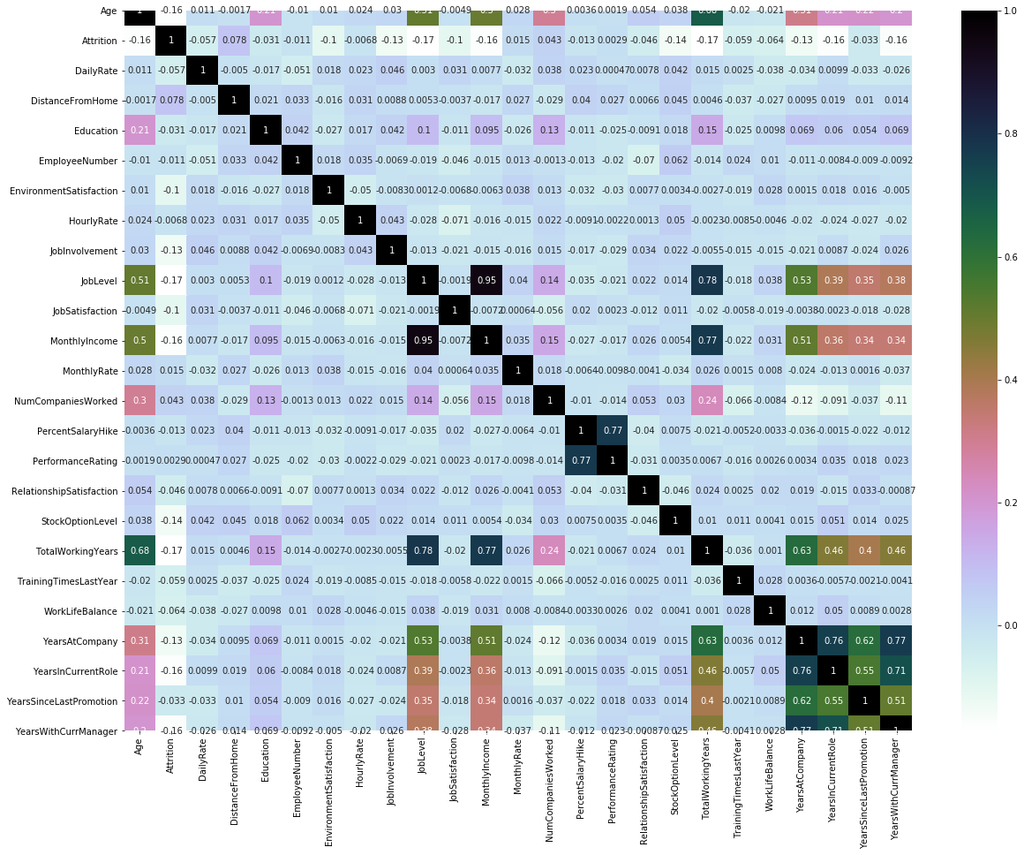

```python
#correlation plot
plt.figure(figsize=(20,15))
sns.heatmap(data.corr(),annot=True,cmap='cubehelix_r')
plt.show();
```

Takeaway from the plots

From the correlation plots, we can see that quite a lot of our columns seem to be poorly correlated with one another. Generally when making a predictive model, it would be preferable to train a model with features that are not too correlated with one another so that we do not need to deal with redundant features. In the case that we have quite a lot of correlated features one could perhaps apply a technique such as Principal Component Analysis (PCA) to reduce the feature space.